# Apartado2_DEGtask

Marcos Rubio Fernandez

2023-April

# Sofware utilizado

Para este trabajo se han utilizado las siguientes versiones de R y paquetes de R:

```
## [1] "Versión R: 4.2.2"
```

```
## [1] "Versión DESeq2: 1.38.3"
```

```
## [1] "Versión tidyverse: 2.0.0"
```

```
## [1] "Versión pheatmap: 1.0.12"
```

```
## [1] "Versión RColorBrewer: 1.1.3"
```

```
## [1] "Versión vsn: 3.66.0"
```

# Pre-procesado de los datos

Para este análisis partimos de:

1. Matriz de cuentas crudas (“rawcounts.tsv”)
2. Metadatos del experimento (“metadata.tsv”)

Estos datos serán cargados y tratados para que el nombre de las filas de los metadatos (muestras) coincidan con las columnas de la matriz de cuentas.

Adicionalmente crearemos una nueva variable del experimento, la variable `group` que consistirá en la unión de las variables `agent` (tratamiento) y la `time` (tiempo de tratamiento).

```
## [1] "Control24h" "Control48h" "DPN24h"     "DPN48h"     "OHT24h"
## [6] "OHT48h"
```

# Creación de DESeqDataSet

A continuación crearemos el objeto `DESeqDataSet`. Para este objeto, utilizaremos como diseño la modelización por la variable `patient` (paciente) y la variable `group` creada anteriormente. La generación de esta variable nos permite analizar a la vez el tratamiento y el tiempo, en vez de estar utilizando en el diseño la formulación correspondiente la interacción de ambas variables. Se ha decidido realizar esta aproximación siguiendo la recomendación de los autores de DESeq2 en su apartado Interacciones (http://bioconductor.org/packages/devel/bioc/vignettes/DESeq2/inst/doc/DESeq2.html#interactions).

```r
dds <- DESeqDataSetFromMatrix(countData = counts_data,
                               colData = experiment_data,
                               design = ~ patient + group)

dds
```

```
## class: DESeqDataSet
## dim: 53160 24
## metadata(1): version
## assays(1): counts
## rownames(53160): ENSG00000000003 ENSG00000000005 ... ENSG00000257111
##   ENSG00000257112
## rowData names(0):
## colnames(24): GSM913873 GSM913874 ... GSM913895 GSM913896
## colData names(4): patient agent time group
```

De este data set eliminaremos aquellos genes que tengan un número de lecturas inferior a 10, ya que este filtrado no supone alteración en el estudio estadístico y comprobamos que el número de genes ha disminuido.

```
## [1] "El número de genes incialmente es: 53160"
```

```
## [1] "El número de genes tras filtrar aquellos con un número de lecturas > 10 es: 24416"
```

# Análisis exploratorio

Antes de pasar a realizar la expresión diferencial tenemos que revisar nuestros y datos y la aproximación.

## Transformación estabilizadora de la varianza (VST)

Esta función normaliza y estabiliza la varianza de las cuentas (utilizando los size factors), y consiguiendo una matriz que es aproximadamente homocedastica. También tiene en cuenta el tamaño de la libreria.

```r
vsd <- vst(dds2, blind = TRUE)
```

En los siguientes gráficos podemos ver que la estabilización ha ido correctamente ya que la curva (linea roja) de las cuentas (panel izquierdo) se ha aplanado al transformarse (panel derecho). La tercera figura es una alternativa de ver el resultado de VST con respecto a los valores más pequeños.

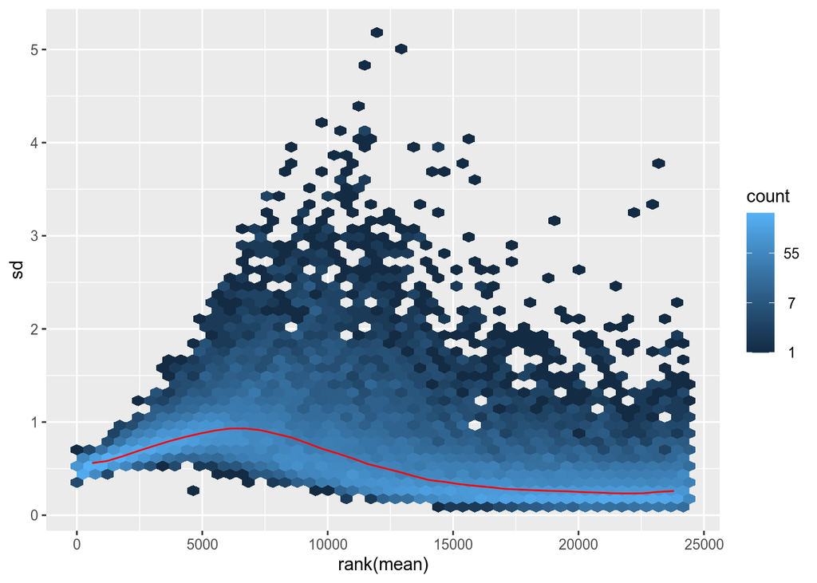

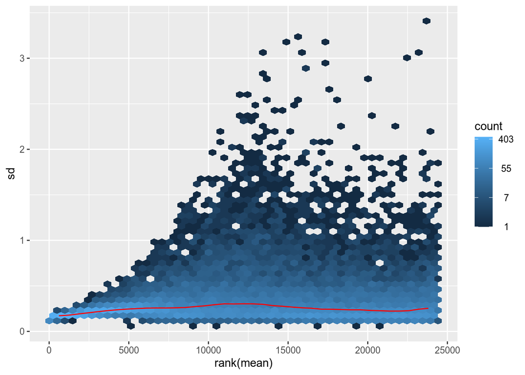

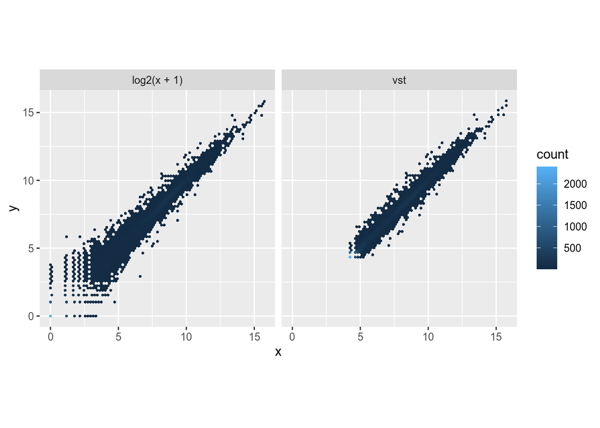

### Análisis de componentes principales (PCA)

Este objeto vsd nos permite trabajar con unos datos preparados para el análisis de componentes principales y clustering de distancias. A continuación mostramos los resultados gráficos del análisis de componentes principales (PCA), en donde podemos observar que los datos se agrupan por su similitud en relación a los pacientes. El tratamiento y el tiempo no separan los grupos. En los gráficos se aprecia la existencia de un **outlier** correspondiente al *paciente 4*, tratamiento *control* y tiempo *24 horas*.

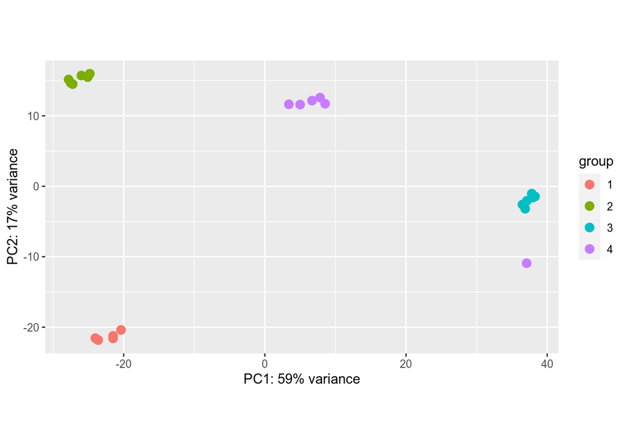

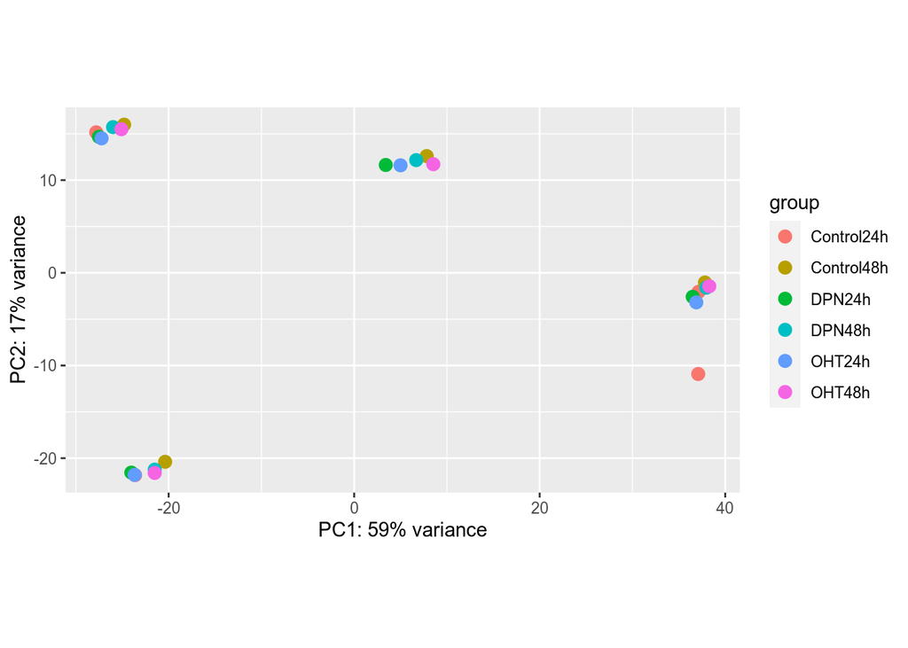

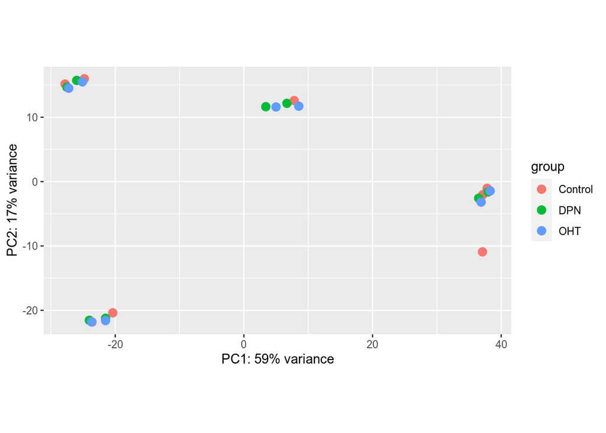

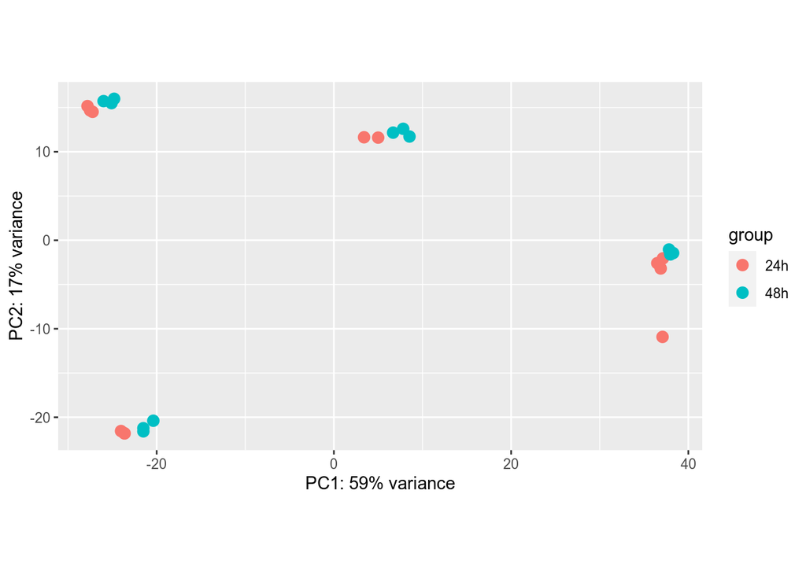

### Matriz de distancias

Alternativamente, podemos comprobar los resultados del PCA mediante una matriz de distancias. En ella podemos ver que los pacientes se agrupan bien entre ellos. En cada paciente los tiempos se agrupan mejor entre ellos (24h vs 48h). Entre los pacientes parece que los pacientes 1 y 2 serían más cercanos entre si, y por otro lado el 3 y el 4. En relación con el **outlier**, comprobamos su existencia también por este método y vemos que, al igual que demostraba el PCA, se encuentra más cercano a los datos del paciente 3 que a los de su propio grupo.

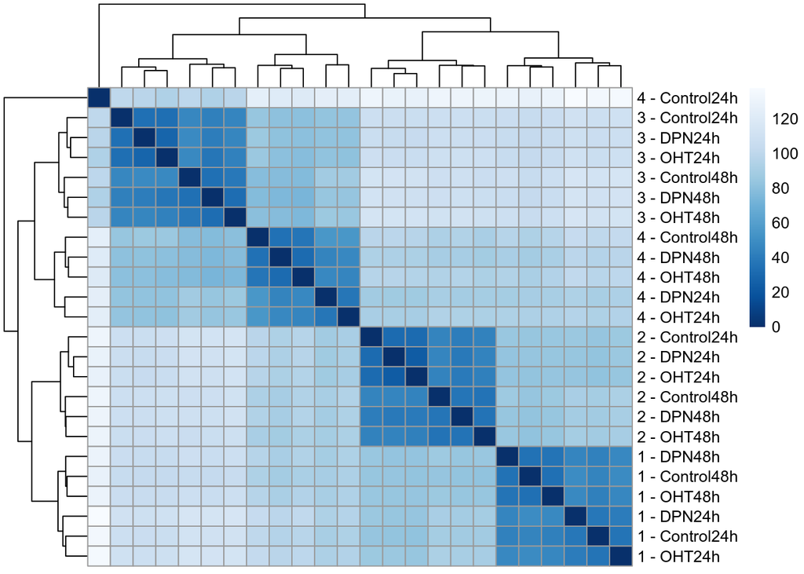

## Análisis de expresión diferencial

### Manejo de outlier

Inicialmente vamos a mantener el outlier detectado en el análisis exploratorio. No suele ser una buena práctica mantener este tipo de datos ya que pueden perturbar el resultado en cuanto a los cálculos de expresión diferencial pero creemos, que en una primera aproximación, podría ser más correcto no perder ningún dato ya que este outlier corresponde al único punto que tenemos para esta medición (Paciente 4 - Control - 24 horas). Posteriormente, si se estima necesario repetiremos el análisis eliminando este punto para comprobar si y como varían los resultados.

### Análisis de expresión diferencial

A continuación creamos un nuevo objeto con la funcion `DESeq`, la cual lleva a cabo el análisis a través de:

- Estimación de los *size factors*
- Estimación de la dispersión
- Ajuste del modelo de GLM - Binomial negativa, y en este caso el estadístico de Wald.

```r
dds3 <- DESeq(dds2, test = "Wald")
```

El gráfico de la izquierda muestra los resultados obtenidos de la dispersión de los datos mediante el método de la máxima probabilidad. Por su parte el gráfico MA-plot de la derecha, nos muestra los resultados de la expresión diferencial dando la variación en log fold de cada gen frente a la media de las cuentas normalizadas, los valores coloreados corresponden con genes diferencialmente expresados.

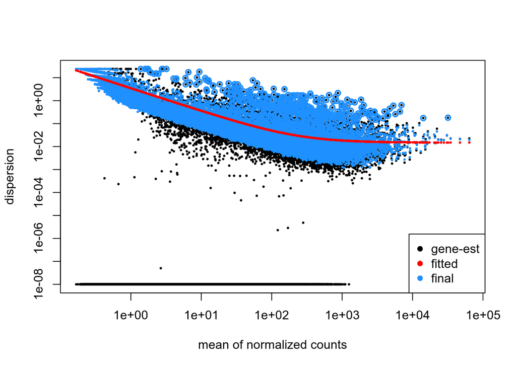

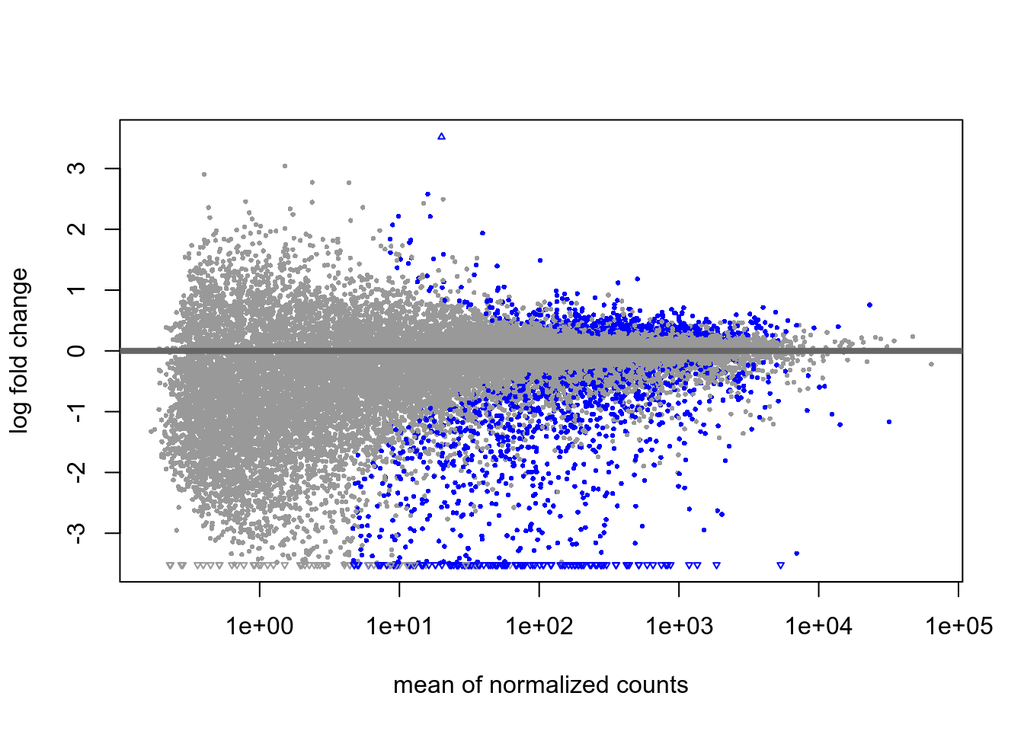

### Efecto del tratamiento con DPN a 24 horas

Para comprobar si el efecto del tratamiento con DPN a 24 horas tiene efecto en la expresión de algunos genes utilizaremos la función `results` del paquete de DESeq2.

```r
res_DPN <- results(object = dds3,
                      contrast = c("group", "Control24h", "DPN24h"),
                      alpha = 0.05,
                      pAdjustMethod = "BH"
                      )
```

En esta función establecemos los diferentes parámetros:

- `object`: identifica el objeto DESeq donde está el modelo ajustado
- `contrast`: las variables que queremos contrastar. En nuestro caso queremos que dentro de la variable `group` compare los datos del `Control24h` con los de `DPN24h`.
- `alpha`: es el valor del nivel de confianza. Lo establecemos en 0,05 % (es decir el 95%).
- `pAdjustMethod`: este análisis nos ofrece el valor de los p-valor para cada gen pero como estamos haciendo múltiples test necesitamos ajustar el p-valor. En este caso aplicamos la corrección de *Benjamini-Hochberg* (BH).

El resultado de este contraste es el que sigue y en ellos podemos ver que el número de genes diferencialmente expresados dado el valor p-valor ajustado < 0.05 es de 87 (74-up, 13-down).

```
##
## out of 24416 with nonzero total read count
## adjusted p-value < 0.05
## LFC > 0 (up)       : 74, 0.3%
## LFC < 0 (down)     : 13, 0.053%
## outliers [1]       : 0, 0%
## low counts [2]     : 10888, 45%
## (mean count < 28)
## [1] see 'cooksCutoff' argument of ?results
## [2] see 'independentFiltering' argument of ?results
```

A continuación podriamos filtrar aquellos genes con un logFoldChange (LFC) superior a 1 (incremento de 2 veces) o de 0.585 (incremento de 1,5 veces) que suelen ser los valores más representativos de un cambio en la expresión. Lo que sucede es que este tipo de análisis *post-hoc* no son una buena práctica. Los autores de DESeq2 describen en su artículo esta situación de la siguente manera:

> *For well-powered experiments, however, a statistical test against the conventional null hypothesis of zero LFC may report genes with statistically significant changes that are so weak in effect strength that they could be considered irrelevant or distracting. A common procedure is to disregard genes whose estimated LFC is below some threshold (0). However, this approach loses the benefit of an easily interpretable FDR, as the reported P value and adjusted P value still correspond to the test of zero LFC. It is therefore desirable to include the threshold in the statistical testing procedure directly, i.e., not to filter post hoc on a reported fold-change estimate, but rather to evaluate statistically directly whether there is sufficient evidence that the LFC is above the chosen threshold.*

Por lo tanto lo correcto sería incluir el valor de LFC que queremos testar en el análisis de `results`, utilizando la opción `lfcThreshold = 1` y obteniendo el resultado de más abajo. Teniendo en cuenta este filtrado, no obtendríamos ningún gen diferencialmente expresado manteniendo un umbral superior a LFC > 1.

```
##
## out of 24416 with nonzero total read count
## adjusted p-value < 0.05
## LFC > 1.00 (up)    : 0, 0%
## LFC < -1.00 (down) : 0, 0%
## outliers [1]       : 0, 0%
## low counts [2]     : 0, 0%
## (mean count < 0)
## [1] see 'cooksCutoff' argument of ?results
## [2] see 'independentFiltering' argument of ?results
```

Por otra parte, los mismos autores también refieren los siguiente en el artículo:

> *For small-scale experiments, statistical significance is often a much stricter requirement than biological significance, thereby relieving the researcher from the need to decide on a threshold for biological significance.*

Por lo que consideraremos nuestro experimento como de pequeña escala (bajo número de muestras y bajo número de réplicas por cada una) y continuaremos el análisis con los datos **sin** el filtro de `lfcThreshold`.

### Efecto del tratamiento con OHT a 24 horas

A continuación repetiremos el contraste pero esta vez utilizando el segundo tratamiento a 24 horas. En este caso podemos ver en los resultados a continuación que el número de genes (48) es menor que para DPN, siendo 44 up y 4 down para el LFC.

```r
res_OHT <- results(object = dds3,
                      contrast = c("group", "Control24h", "OHT24h"),
                      alpha = 0.05,
                      pAdjustMethod = "BH"
                      )
summary(res_OHT)
```

```
##
## out of 24416 with nonzero total read count
## adjusted p-value < 0.05
## LFC > 0 (up)       : 44, 0.18%
## LFC < 0 (down)     : 4, 0.016%
## outliers [1]       : 0, 0%
## low counts [2]     : 5681, 23%
## (mean count < 2)
## [1] see 'cooksCutoff' argument of ?results
## [2] see 'independentFiltering' argument of ?results
```

De la misma forma que en el tratamiento anterior, evaluaremos el mismo contraste pero estableciendo el parámetro `lfcThreshold = 1` a priori. Con este filtrado hemos obtenido un único gen diferencialmente expresado (ENSG00000240864). Por lo tanto, vamos a actuar de la misma forma que con DPN y utilizaremos los datos del contraste **sin** filtrar por LFC.

```
##
## out of 24416 with nonzero total read count
## adjusted p-value < 0.05
## LFC > 1.00 (up)    : 1, 0.0041%
## LFC < -1.00 (down) : 0, 0%
## outliers [1]       : 0, 0%
## low counts [2]     : 0, 0%
## (mean count < 0)
## [1] see 'cooksCutoff' argument of ?results
## [2] see 'independentFiltering' argument of ?results
```

```
## [1] "El gen que sale significativo es: ENSG00000240864"
```

### Visualización resultados

Una forma que tenemos para representar los resultados son los heatmap, en este caso representaremos los 30 genes con menor p-valor ajustado de ambos contrastes, utilizando los resultados **sin** filtro lfc = 1.

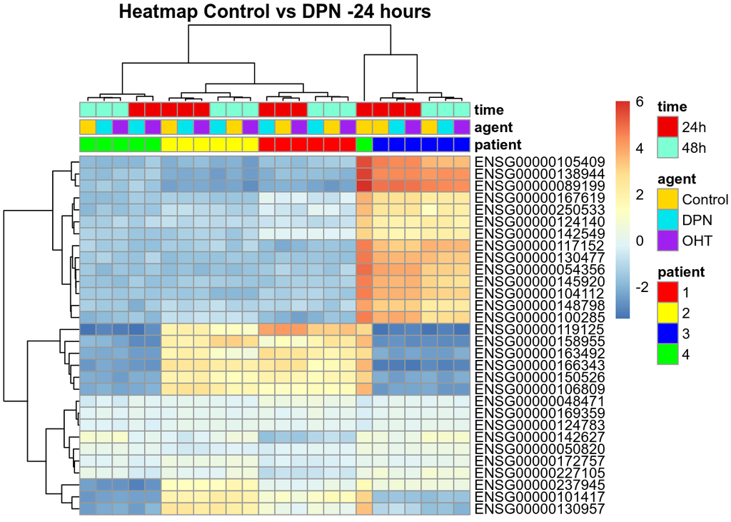

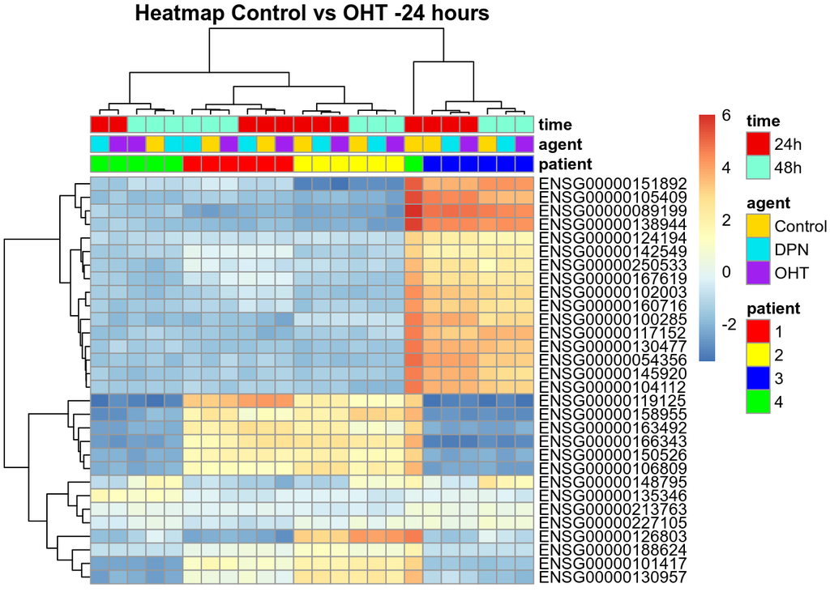

# Outlier

Dada la importancia que parece tener este dato, con valores de expresión (diferencial) de los más altos hemos decidido tratar los datos para eliminarlo. Para este tratamiento de datos podríamos optar por dos aproximaciones:

1. Eliminar todos los datos relativos al paciente 4: quizás esta aproximación sería la más conservadora y correcta viendo el diseño experimental donde no tenemos más que una réplica por condición. Por lo que haciendo esto no dejariamos “descolgadas” las comparaciones de los tratamientos.
2. Eliminar unicamente el dato *outlier*, correspondiente con el paciente 4, tratamiento control y tiempo 24 horas.

Para este ejercicio hemos decidido realizar esta última, aunque como comentamos puede que no sea lo idóneo pero así podemos evaluar (o eso creo) la influencia de este dato sobre el resto del análisis mientras que si eliminamos el grupo entero no podríamos evaluarlo de manera tan concreta.

Creamos nuestro `DESeqDataSet` con nuevas matrices de cuentas y metadatos sin el outlier, como diseño mantenemos `design = ~ patient + group`. Filtraremos las cuentas con valores menores de 10. Como en el anterior análisis vemos la reducción (casi a la mitad) en el número de genes.

```
## class: DESeqDataSet
## dim: 53160 23
## metadata(1): version
## assays(1): counts
## rownames(53160): ENSG00000000003 ENSG00000000005 ... ENSG00000257111
##   ENSG00000257112
## rowData names(0):
## colnames(23): GSM913873 GSM913874 ... GSM913894 GSM913895
## colData names(4): patient agent time group
## [1] "El número de genes incialmente es: 53160"
## [1] "El número de genes tras filtrar aquellos con un número de lecturas > 10 es: 23233"
```

Procedemos con la **transformación estabilizadora de la varianza (VST)**, y mediante los gráficos construidos comprobamos que ha sucedido correctamente.

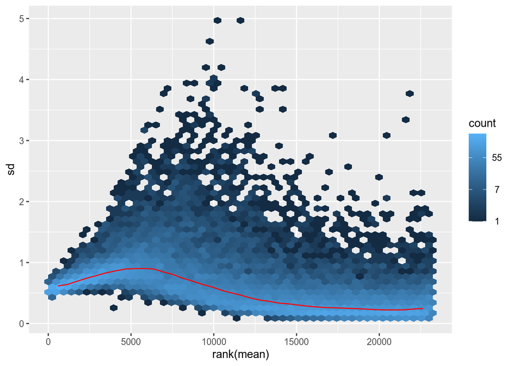

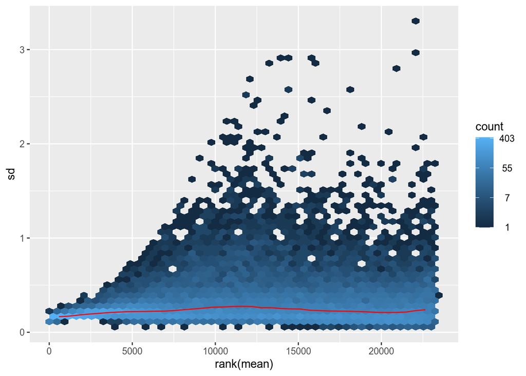

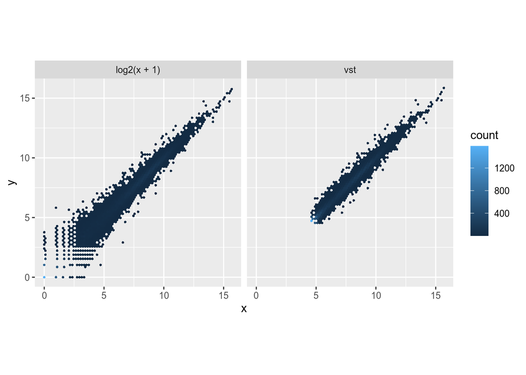

Una vez realizado esto comprobamos de nuevo el **análisis de componentes principales (PCA)** y la **matriz de distancias**, en los cuales vemos que la separación se sigue manteniendo por pacientes pero ya no existe el outlier.

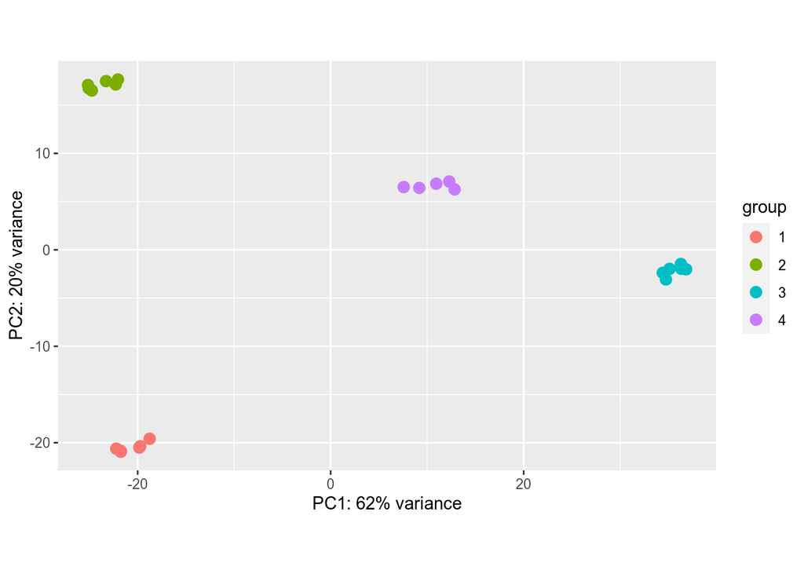

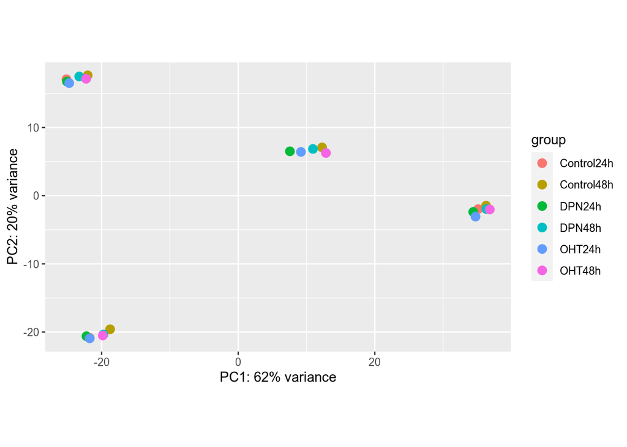

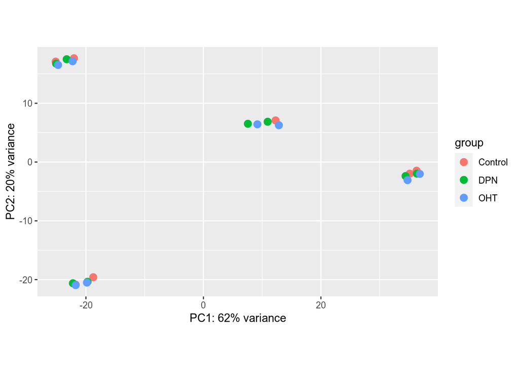

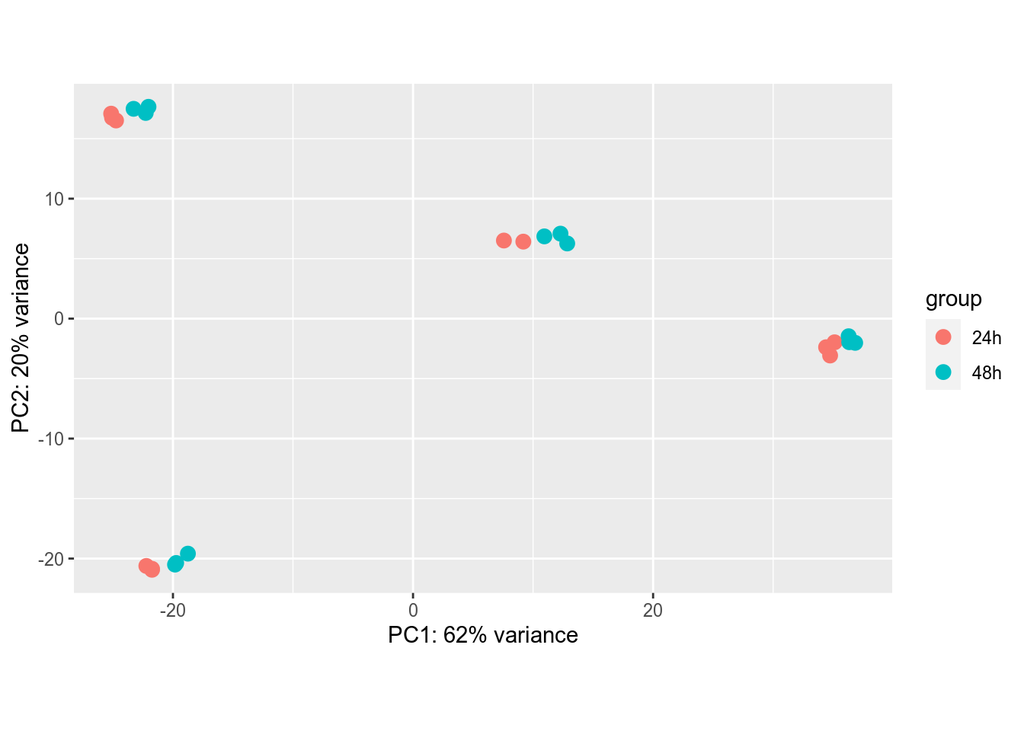

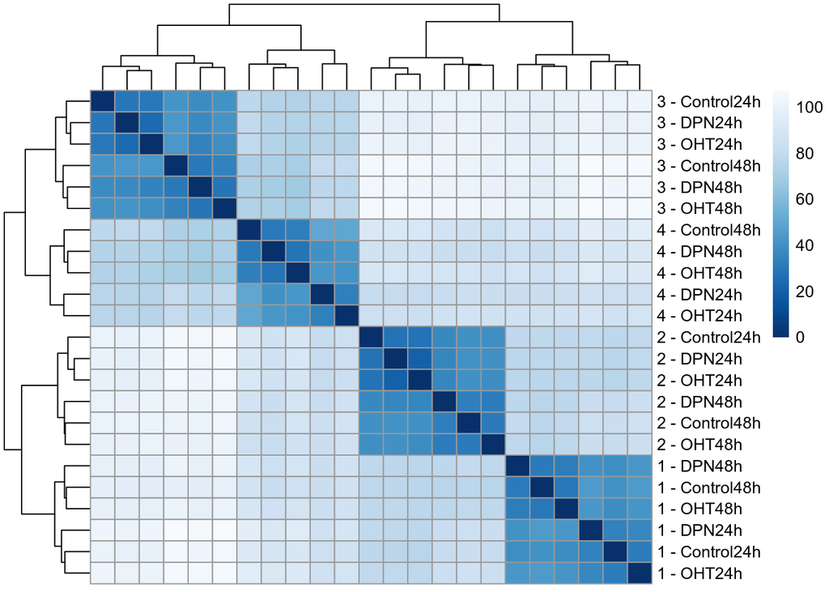

El siguiente paso que haremos es crear nuestro objeto DESeq y comprobar graficamente la distribución de la estimación de la dispersión así como los resultados de la expresión diferencial en el **MA-plot**. De este último podemos resaltar que es diferente con respecto al primer MA-plot obtenido (ver resultados anteriores). En el anterior análisis, muchos de los genes con pvalores significativos se localizan en rangos de logFoldChange negativos, además de ser mucho más abundantes, en este nuevo análisis la mayoria de esos genes con LFC negativo han desaparecido. Esto puede ser indicativo de la influencia que tenia este outlier dentro del análisis de expresión diferencial.

```r
dds3_outlier <- DESeq(dds2_outlier, test = "Wald")
```

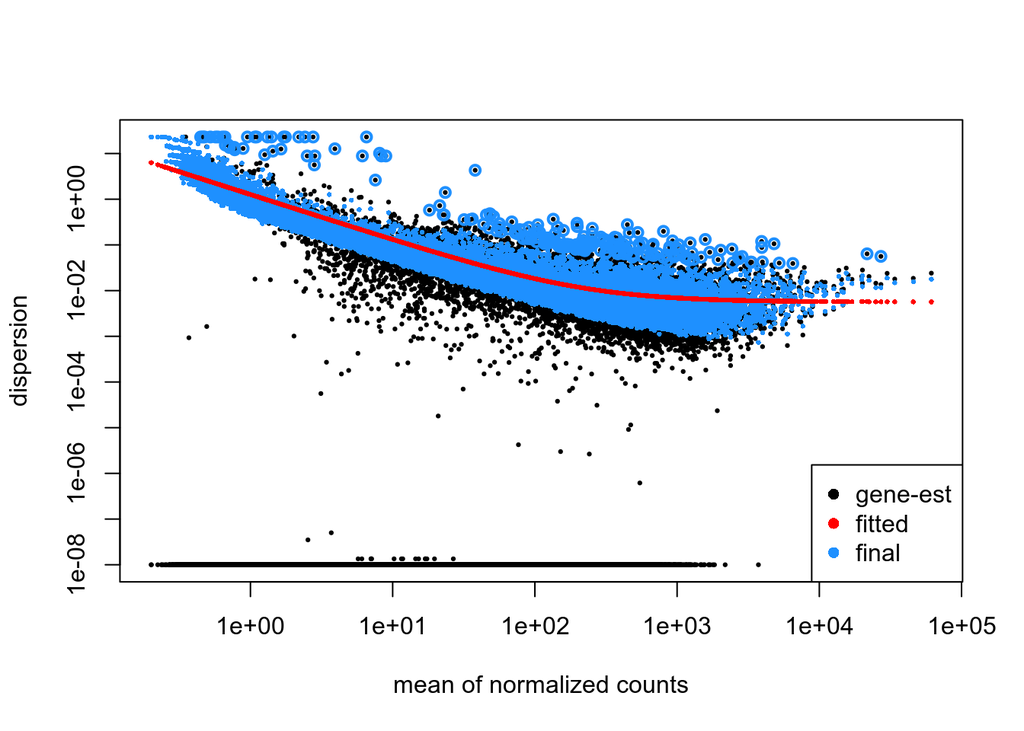

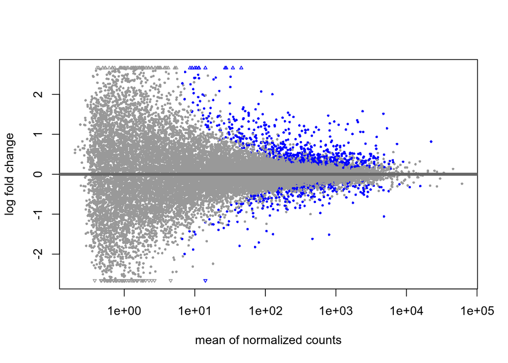

A continuación analizamos los resultados del contraste del **tratamiento con DPN a 24 horas**, y lo que podemos observar es que el número de genes se ha reducido drasticamente tras eliminar este outlier (pasado de casi 90 a 5).

```
## [1] "Summary Control-DPN24h sin lfcThreshold"
```

```
##
## out of 23233 with nonzero total read count
## adjusted p-value < 0.05
## LFC > 0 (up)       : 3, 0.013%
## LFC < 0 (down)     : 2, 0.0086%
## outliers [1]       : 0, 0%
## low counts [2]     : 0, 0%
## (mean count < 0)
## [1] see 'cooksCutoff' argument of ?results
## [2] see 'independentFiltering' argument of ?results
```

```
## [1] "Summary Control-DPN24h, lfcThreshold = 1"
```

```
##
## out of 23233 with nonzero total read count
## adjusted p-value < 0.05
## LFC > 1.00 (up)    : 0, 0%
## LFC < -1.00 (down) : 0, 0%
## outliers [1]       : 0, 0%
## low counts [2]     : 0, 0%
## (mean count < 0)
## [1] see 'cooksCutoff' argument of ?results
## [2] see 'independentFiltering' argument of ?results
```

Asimismo, para el **tratamiento con OHT a 24 horas**, la reducción es igual llegando incluso en este caso a no aparecer ningún gen diferencialmente expresado (tanto con como sin filtro por LFC).

```
## [1] "Summary Control-OHT24h sin lfcThreshold"
```

```
##
## out of 23233 with nonzero total read count
## adjusted p-value < 0.05
## LFC > 0 (up)       : 0, 0%
## LFC < 0 (down)     : 0, 0%
## outliers [1]       : 0, 0%
## low counts [2]     : 0, 0%
## (mean count < 0)
## [1] see 'cooksCutoff' argument of ?results
## [2] see 'independentFiltering' argument of ?results
```

```
## [1] "Summary Control-OHT24h, lfcThreshold = 1"
```

```
##
## out of 23233 with nonzero total read count
## adjusted p-value < 0.05
## LFC > 1.00 (up)    : 0, 0%
## LFC < -1.00 (down) : 0, 0%
## outliers [1]       : 0, 0%
## low counts [2]     : 0, 0%
## (mean count < 0)
## [1] see 'cooksCutoff' argument of ?results
## [2] see 'independentFiltering' argument of ?results
```

### Visualización resultados

Este efecto de reducción en los genes que antes se detallaban como diferencialmente expresados también se puede observar en los heatmap, en ellos tras eliminar el outlier no aparecen grupos de genes diferencialmente expresados.

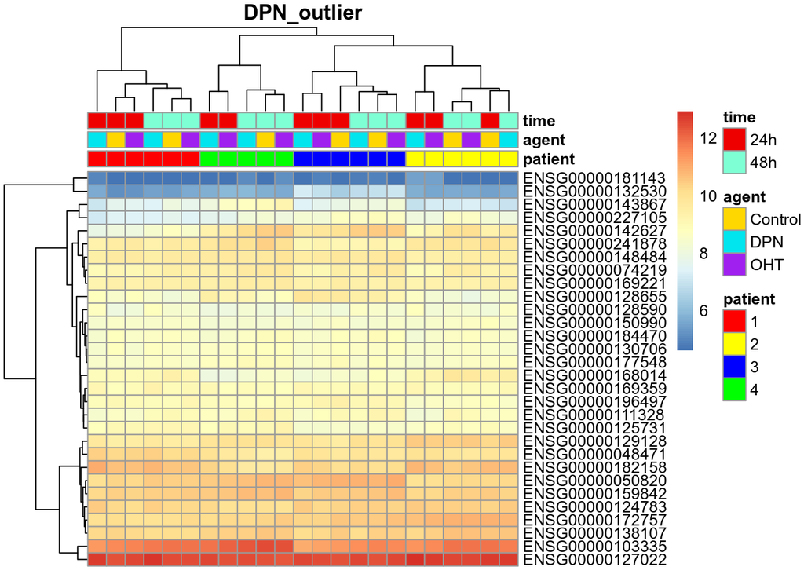

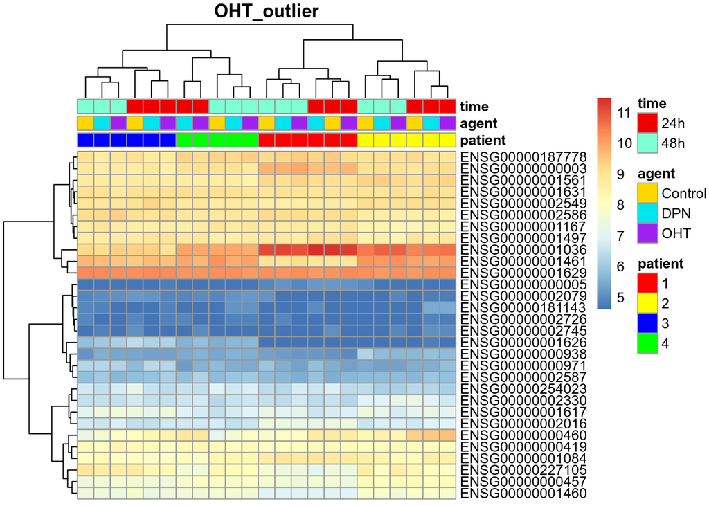

# Conclusiones

1. El análisis preeliminar de los datos de este experimento nos indica que las diferencias en la expresión génica que se podrían observar en los datos están siendo debidas principalmente a las diferencias individuales entre los pacientes en lugar de las diferencias debidas a los tratamientos o tiempos. Esto puede ser una indicación de que hay una alta variabilidad entre los pacientes que está afectando los resultados, aunque esto no necesariamente significa que los tratamientos y tiempos no tengan efectos significativos en la expresión génica.
2. El análisis con DESeq2 muestra una cantidad baja de genes diferencialmente expresados con ambos tratamientos a 24 horas: 87 para DPN y 48 para OHT. Este número suele ser más elevado teniendo en cuenta la gran cantidad de genes que tenemos. Aun con ello, si nos fijamos en las aproximaciones que nos da heatmap para los genes *top* podemos ver que la agrupación de estos genes no se produce por los tratamientos ni por los tiempos (lo que corrobora PCA), si no que se agrupan por los pacientes. No encontrandose por lo tanto genes diferencialmente expresados debido a alguna de estas variables.
3. El tratamiento de los datos para eliminar un outlier del paciente 4 hace que todo el análisis de DEGs desaparezca, no encontrandose (casi) ningún gen ya diferencialmente expresado entre pacientes ni entre condiciones. Esto podría ser indicativo de la influencia que tenian los datos de este paciente. Una solución podría ser incluir un mayor número de pacientes y replicas de cada condición por paciente (ahora mismo solo tenemos un dato por condición y paciente).

```r
as.data.frame(resOrdered_1)
```

|  | baseMean | log2FoldChange | lfcSE | stat | pvalue | padj |
| --- | --- | --- | --- | --- | --- | --- |
| ENSG00000050820 | 1500.20251 | 0.3035073 | 0.06504031 | 4.666449 | 3.064494e-06 | 0.006551901 |
| ENSG00000101417 | 259.67642 | 5.4027104 | 1.15456674 | 4.679427 | 2.876782e-06 | 0.006551901 |
| ENSG00000105409 | 652.62555 | 6.4609432 | 1.37769008 | 4.689693 | 2.736155e-06 | 0.006551901 |
| ENSG00000138944 | 806.33463 | 6.0212515 | 1.30386579 | 4.617999 | 3.874572e-06 | 0.006551901 |
| ENSG00000142627 | 810.09187 | 0.5137021 | 0.10922097 | 4.703329 | 2.559540e-06 | 0.006551901 |
| ENSG00000145920 | 289.56875 | 6.1137656 | 1.31437726 | 4.651454 | 3.296026e-06 | 0.006551901 |
| ENSG00000169359 | 483.87865 | -0.3351788 | 0.07214934 | -4.645626 | 3.390475e-06 | 0.006551901 |
| ENSG00000172757 | 1419.03914 | 0.2519971 | 0.05199844 | 4.846243 | 1.258211e-06 | 0.006551901 |
| ENSG00000054356 | 427.30089 | 5.4698086 | 1.19818488 | 4.565079 | 4.993064e-06 | 0.007505129 |
| ENSG00000150526 | 201.95922 | 6.1667992 | 1.38200950 | 4.462197 | 8.112345e-06 | 0.010974380 |

[output cut: 77 more lines]